# Data analysis of the biological replicates

This notebook analyses the biological replicates and generates a box plot with the copy number for different clones.

- Select values for global variables:
  - *PLOIDY* indicates the ploidy of the cell line studied.
  - *ASSAY*:
    - *dual_color*: two-fluorophores dPCR assay to assess specific or total number of integrations (first color) normalized against genomic DNA loading (second color).
    - *dual_color_all_tag_only*: dual-fluorophore dPCR assay to assess total number of tag integrations in the target genome (first color) normalized against the genomic DNA amount (second color)
    - *triple_color*: three-fluorophores based dPCR assay to assess at the same time specific and total number of integrations (first and second color) both normalized against the same DNA loading amount (third color).
  - *CONTROL_LABELS*: substrings of the sample names indicating when a sample is a control.

```r
PLOIDY <- 3

ASSAY <- "dual_color"
# ASSAY <- "dual_color_all_tag_only"
# ASSAY <- "triple_color"

CONTROL_LABELS <- c("U2OS", "Nup96", "Nup62", "NTC", "Comp", "wt", "HK-wt")
```

- Import functions.

```r
source("functions.R")
```

### Pre-processing data

```r
samplesToDiscard <- unique(grep(paste(CONTROL_LABELS, collapse="|"), dataREPLICATES$Sample, value=TRUE))
dataREPLICATES  <- dataREPLICATES[!(dataREPLICATES$Sample %in% samplesToDiscard),]
```

- Remove samples with 0 positives:

```r
dataREPLICATES <- dataREPLICATES[dataREPLICATES$Positives!=0,]
```

- Extract **Group** from the **Sample** name:

```r
dataREPLICATES <- extractGroup(dataREPLICATES, ASSAY)
```

- Number of samples for each marker and target type:

```r
knitr::kable(table(dataREPLICATES[c("Marker","TargetType")]))
```

|  | REFERENCE | TARGET |
| --- | --- | --- |
| GFP | 20 | 20 |
| HDR | 15 | 15 |

### Compute parameters

- Compute the **Negative Rate**:

```r
dataREPLICATES$NegativeRate <- computeNegativeRate(dataREPLICATES)
```

- Compute the **Ratio** and the **Confidence Interval**:

```r
dataREPLICATES <- computeConfidenceInterval(dataREPLICATES)
```

- Compute **Relative Error**:

```r
dataREPLICATES <- computeRelativeError(dataREPLICATES)
```

- Update the **Ratio** with the ploidy:

```r
dataREPLICATES$Ratio <- PLOIDY * dataREPLICATES$Ratio
```

### Quality Control

- Keep only samples with relative error < 20 %.

```r
dataREPLICATES <- dataREPLICATES[dataREPLICATES$RelErr < 0.2,]
```

### Box plot with the copy numbers by clone

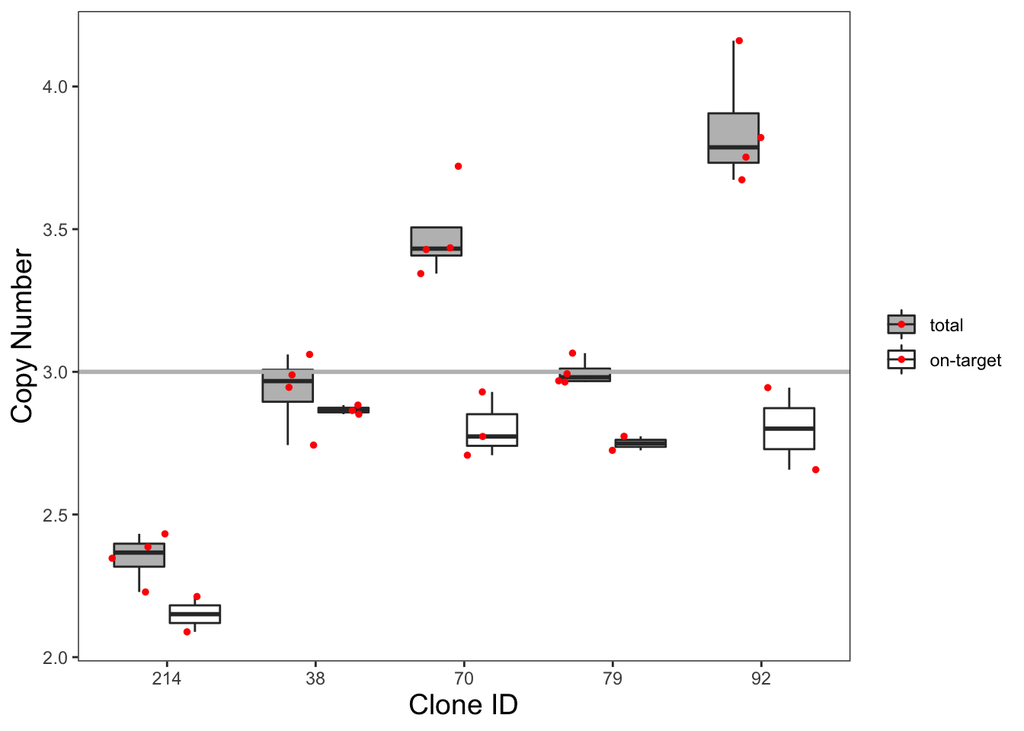